# *What are the origins of the extreme flooding in Southeastern China?*

Kylie Wong

03/01/2019

## Introduction

As China continues to climb up the global ranks with its recent goals for technological advancements and urban development, the natural landscape of the country is put at risk. Specifically in Southeast China, where urban development is centralized around the entire Pearl River Delta, large cities like Guangzhou and many others are at a high risk of flooding. As a result, the urban infrastructure is threatened. In addition, the entire livelihood of Chinese citizens are threatened with the high frequency of flash floods. The heavy rainfall and flooding in Southeast China in the summer of 2016 generated $1.1 billion in damages, left 200,000 people without a home, and took 36 lives (NSSL). With climate change escalating extreme weather trends, the frequency of these floods are likely to increase, costing more lives and creating more damages.

In this blog, I will attempt to explore the origins of the floods in the Pearl River Basin of South China, and what triggers the intensity of the floods. In addition, I will analyze the impacts of the floods on the socio-economic infrastructure of Southeast China; therefore, I hypothesize that the intensity of rainfall is correlated to the power of flash floods in South China, which would lead to detrimental effects the socio-economic infrastructure in China.

###### How are floods and precipitation related?

Floods occur after heavy and overflowing rainfall on land that is usually dry. The most dangerous floods are flash floods, which can flood an entire region in a short amount of time with high intensity. What makes these flood even more dangerous is its unpredictability, which can easily devastate a region that is under-prepared and also densely populated like Southeastern China.

## Guangzhou, China Temperature Graph

(this may not be relevant to my research)

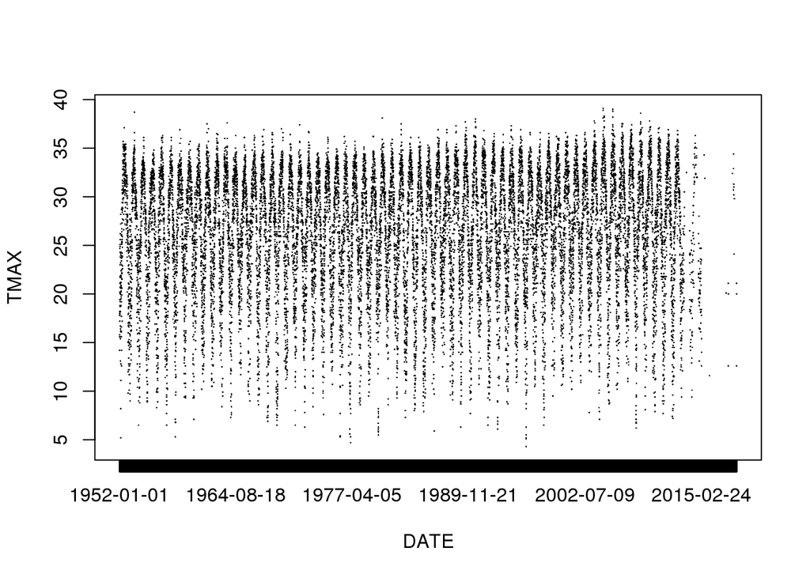

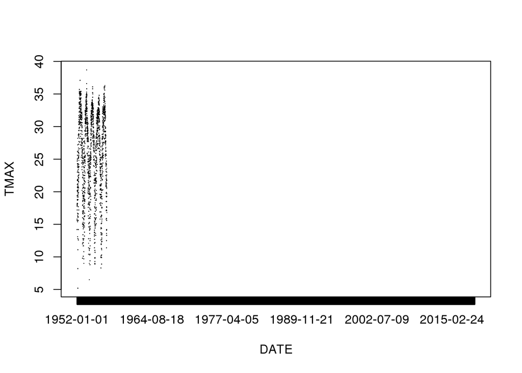

```
## 'data.frame':    24472 obs. of  7 variables:
##  $ STATION: Factor w/ 1 level "CHM00059287": 1 1 1 1 1 1 1 1 1 1 ...
##  $ NAME   : Factor w/ 1 level "GUANGZHOU, CH": 1 1 1 1 1 1 1 1 1 1 ...
##  $ DATE   : Factor w/ 24472 levels "1952-01-01","1952-01-02",..: 1 2 3 4 5 6 7 8 9 10 ...
##  $ PRCP   : num  0 0 0 0 0 0 0 0 0 0 ...
##  $ TAVG   : num  12.6 11.6 11.5 13 14.8 14.1 11.7 9.2 11.3 15.8 ...
##  $ TMAX   : num  14.2 15.8 17.8 18 18.2 19.4 15.6 15.6 17.2 20.2 ...
##  $ TMIN   : num  11.1 8.5 7.4 8.1 11 9.9 8.1 5.2 5.5 12.8 ...
```

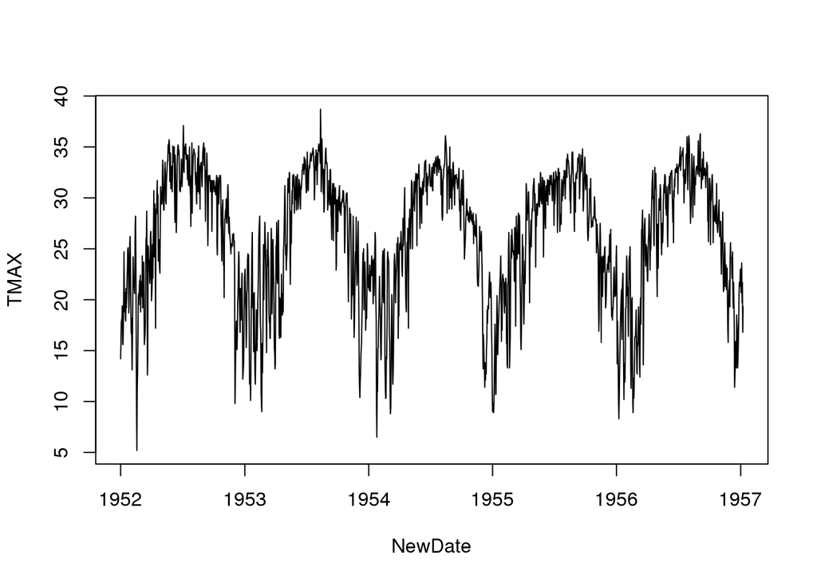

```
##
## Call:
## lm(formula = TMAX ~ NewDate, data = climate_data)
##
## Coefficients:
## (Intercept)      NewDate
##    2.63e+01     3.67e-05
```

```
##
## Call:
## lm(formula = TMAX ~ NewDate, data = climate_data)
##
## Residuals:
##     Min      1Q  Median      3Q     Max
## -22.352  -4.162   1.229   5.182  12.618
##
## Coefficients:
##              Estimate Std. Error t value Pr(>|t|)
## (Intercept) 2.630e+01  5.197e-02 506.087  < 2e-16 ***
## NewDate     3.670e-05  6.493e-06   5.652  1.6e-08 ***
## ---
## Signif. codes:  0 '***' 0.001 '**' 0.01 '*' 0.05 '.' 0.1 ' ' 1
##
## Residual standard error: 6.328 on 22485 degrees of freedom
##   (1985 observations deleted due to missingness)
## Multiple R-squared:  0.001419,   Adjusted R-squared:  0.001374
## F-statistic: 31.95 on 1 and 22485 DF,  p-value: 1.604e-08
```

```
## 'data.frame':    762 obs. of  5 variables:
##  $ Month: chr  "01" "02" "03" "04" ...
##  $ Year : chr  "1952" "1952" "1952" "1952" ...
##  $ TMAX : num  20.3 18.9 21.7 26.1 32.3 ...
##  $ YEAR : num  1952 1952 1952 1952 1952 ...
##  $ MONTH: num  1 2 3 4 5 6 7 8 9 10 ...
```

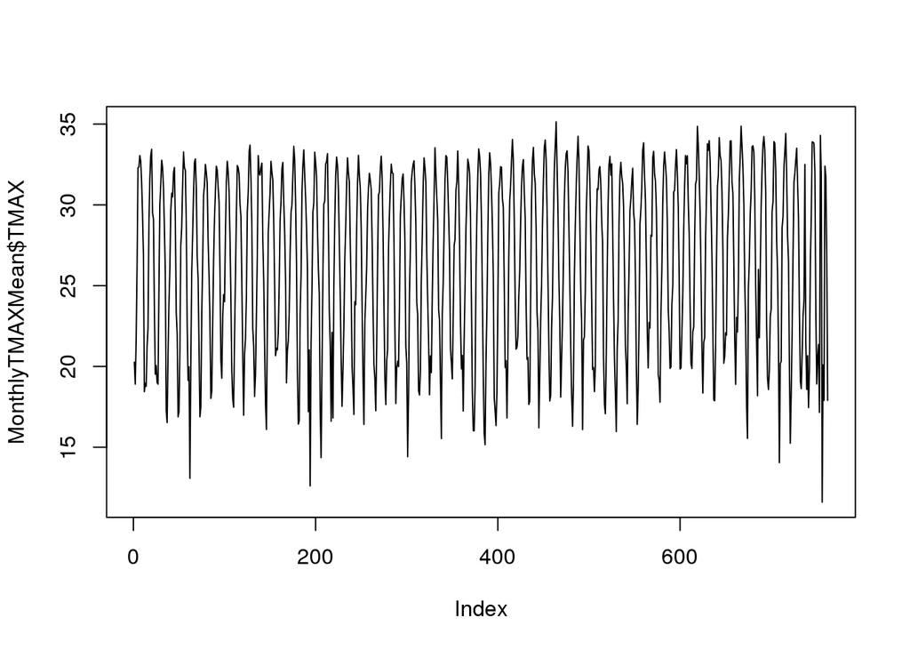

```
##
## Call:
## lm(formula = TMAX ~ YEAR, data = MonthlyTMAXMean[MonthlyTMAXMean$Month ==
##     "05", ])
##
## Residuals:
##     Min      1Q  Median      3Q     Max
## -1.8548 -0.7539 -0.1097  0.6424  3.5590
##
## Coefficients:
##              Estimate Std. Error t value Pr(>|t|)
## (Intercept) 11.572042  15.605396   0.742    0.461
## YEAR         0.009131   0.007871   1.160    0.251
##
## Residual standard error: 1.111 on 60 degrees of freedom
## Multiple R-squared:  0.02194,    Adjusted R-squared:  0.005635
## F-statistic: 1.346 on 1 and 60 DF,  p-value: 0.2506
```

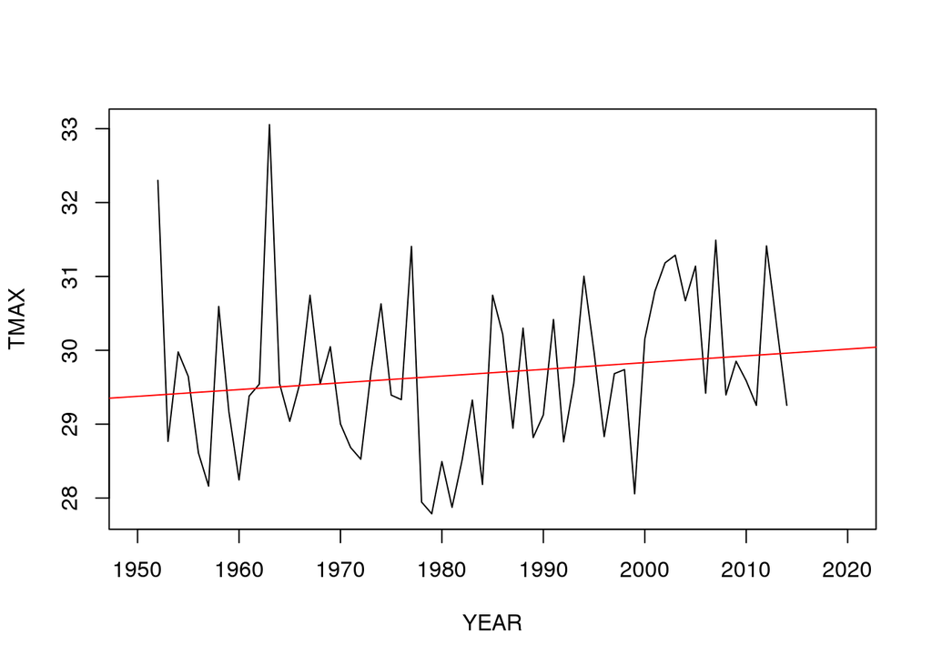

```
##   Month Year     TMIN YEAR MONTH
## 1    01 1952 11.02581 1952     1
## 2    02 1952 12.14138 1952     2
## 3    03 1952 15.40000 1952     3
## 4    04 1952 18.61000 1952     4
## 5    05 1952 24.98065 1952     5
## 6    06 1952 25.67000 1952     6
```

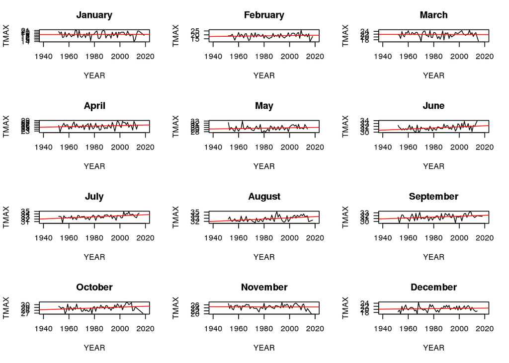

[figure not shown]